# Premières manipulations avec R

# 11 Exercice #3

1. Écrire une fonction qui prend en argument un vecteur de valeurs numériques et qui le centre et le réduit , c’est-à-dire qui soustrait à chaque valeur la moyenne du vecteur et qui divise par la valeur de l’écart-type . Vous pouvez tester votre fonction avec un vecteur initialisé par vos soins, un dataframe de votre choix ou le dataframe `iris`.
2. Afficher l’histogramme du vecteur centré et réduit.

Voici quelques façons alternatives de générer des vecteurs: (Reportez-vous à la documentation des fonctions pour en saisir le fonctionnement)

```r
# répéter un motif
rep(c(1,5,10),10)
```

```
##  [1]  1  5 10  1  5 10  1  5 10  1  5 10  1  5 10  1  5 10  1  5 10  1  5 10  1
## [26]  5 10  1  5 10
```

```r
# discrétiser un intervalle en précisant le quantum
seq(from= 25 , to = 250, by = 22 )
```

```
##  [1]  25  47  69  91 113 135 157 179 201 223 245
```

```r
# discrétiser un intervalle en précisant la longueur
seq(from= 25 , to = 250, length.out = 10 )
```

```
##  [1]  25  50  75 100 125 150 175 200 225 250
```

```r
# échantillonner une loi uniforme entre deux valeurs
runif(25, min=  -15 , max = 8 )
```

```
##  [1] -14.4902296   5.6933793  -3.6315929  -4.4941162  -0.6184900   0.5723301
##  [7]   1.0891739  -1.4851965   1.7661029   0.9872808 -10.3775103  -7.6925242
## [13]   4.5041788   3.5595113  -6.5881617   0.2061425   2.5525713  -8.2842719
## [19]  -2.9229696   6.3902136 -10.4139784 -11.1224093 -12.4700367  -0.9625716
## [25]  -4.2616182
```

```r
# échantilloner une loi normale de moyenne et d'écart-type donné
rnorm(25, m = 12 , sd = 2)
```

```
##  [1] 14.344007 14.291891 12.854251 13.951180 12.444980 11.739217  8.023617
##  [8] 11.205747 11.570633 10.725751 12.589172 13.037297 12.816218 11.110024
## [15] 12.405038 10.464810 12.362279 10.174128 11.464521  9.929490 11.476749
## [22] 16.328529 14.028853 10.237980 11.613314
```

# 12 Entrées/sorties : fichier CSV

Nous ne traiterons ici que de la lecture de fichiers au format CSV. Des packages spécifiques existent pour interagir avec des bases de données, le format json et les feuilles MS Excel.

## 12.1 Lecture de fichier

On vous fournit un fichier intitulé `pokemon.csv`. Les fichiers de format CSV contiennent des données tabulaires : ils sont donc transformées en dataframe par R.

Pour le lire on peut utiliser la fonction de base `read.csv()`. En cas de fichier particulièrement gros (plusieurs centaines de mega-octets) on pourrait se tourner vers les fonctions `read_csv()` du package `data.table`, plus adaptées à ces volumes.

```r
pokemon_df  <-  read.csv("~/coursDESIGEO/pokemons.csv")
str(pokemon_df)
```

[output not shown]

L’appel de la fonction `read.csv` avec tous les arguments par défaut fonctionne correctement. La fonction `str()` nous donne la structure du dataframe : les noms et type de ses variables.

La fonction `read.csv` , lorsque le fichier est bien constitué (pas de trous, nombre constant de colonnes, caractères exprimés dans un charset reconnu, etc…), “devine” le type des colonnes.

Pour changer ce comportement , il faut passer en argument à `read.csv()` l’argument `stringsAsFactors=FALSE` (cf la documentation de la fonction)

Parfois, ce comportement de la fonction apr défaut est discutable.

### 12.1.1 Type des colonnes d’un fichier CSV

Ici par exemple , le nom des pokemons est considéré comme un facteur à … 800 modalités (pour 800 individus) : ce qui est peu pertinent, chaque nom étant a priori unique et propre à chaque individu de la population de pokemons ; par ailleurs il est peu probable de devoir faire des regrouppements par nom.

Nous pouvons changer le type de la variable `Name` en utilisant la fonction `as.character()` sur la colonne du dataframe pour la remplacer.

```r
pokemon_df$Name <-  as.character(pokemon_df$Name)
```

Autre problème : les valeurs de la variable `Legendary` sont reconnues comme des facteurs à deux modalités `"True"` et `"False"` alors que leurs valeurs sont clairement booléennes.

La fonction `as.logical()` est capable de transformer automatiquement les valeurs `"T", "TRUE", "True", "true"` en la valeur `TRUE` du langage R (de meme pour les variations de la valeurs `False`)

```r
pokemon_df$Legendary <-  as.logical(pokemon_df$Legendary)
```

Enfin , la colonne `X` ne semble pas receler d’informations très intéressantes, à votre avis d’où vient-elle ?  
Peut-on la supprimer ?

```r
str(pokemon_df)
```

```
## 'data.frame':    800 obs. of  13 variables:
##  $ X.        : int  1 2 3 3 4 5 6 6 6 7 ...
##  $ Name      : chr  "Bulbasaur" "Ivysaur" "Venusaur" "VenusaurMega Venusaur" ...
##  $ Type.1    : chr  "Grass" "Grass" "Grass" "Grass" ...
##  $ Type.2    : chr  "Poison" "Poison" "Poison" "Poison" ...
##  $ Total     : int  318 405 525 625 309 405 534 634 634 314 ...
##  $ HP        : int  45 60 80 80 39 58 78 78 78 44 ...
##  $ Attack    : int  49 62 82 100 52 64 84 130 104 48 ...
##  $ Defense   : int  49 63 83 123 43 58 78 111 78 65 ...
##  $ Sp..Atk   : int  65 80 100 122 60 80 109 130 159 50 ...
##  $ Sp..Def   : int  65 80 100 120 50 65 85 85 115 64 ...
##  $ Speed     : int  45 60 80 80 65 80 100 100 100 43 ...
##  $ Generation: int  1 1 1 1 1 1 1 1 1 1 ...
##  $ Legendary : logi  FALSE FALSE FALSE FALSE FALSE FALSE ...
```

## 12.2 Écriture de fichier CSV

L’écriture d’un dataframe dans le format CSV se fait avec la fonction `write.csv()` , qui prend en argument un dataframe et un chemin d’accès vers un nouveau fichier :

```r
write.csv( iris, file = "/chemin/vers/repertoire/mon_fichier.csv")
```

De nombreuses options sont possibles : vous pouvez préciser le type de séparateur utilisé, le caractère de fin de ligne, l’écriture des noms de colonnes etc…

# 13 Exercice #4

1. Récupérer les données

Récupérer le fichier `2020_LoL_esports_match_data_from_OraclesElixir_20210124.csv` sur le répertoire partagé de la formation.

Il s’agit de résultats d’une compétition d’e-sport sur le jeu “Leagues of Legend”, qui oppose deux équipes de 5 joueurs. La connaissance du jeu lui même n’est pas nécessaire pour répondre aux questions.^ Une ligne contient les variables qui décrivent **un** match d’**un** joueur

Pour les questions suivantes, faites figurer dans un script R le code qui vous permet de réaliser les étapes suivantes :

2. Lire le fichier
3. Identifier le nombre de colonnes et de lignes du fichier
4. Quel est le type de la colonne `position` et de la colonne `dpm` du jeu de données ?
5. Calculer la valeur moyenne de la colonne `totalgold`
6. A partir du jeu de données initial, on vous demande de créer un second dataframe qui ne contienne que les données des joueurs qui ont perdu les matchs de la compétition . Dans les données , c’est la colonne `result` qui porte cette information, la valeur `0` signifiant une défaite.
7. Sauvegarder le résultat dans un fichier que vous appelez “defeats.csv”
8. Les données sur les matches contiennent une colonne `totalgold` (l’or gagné par les joueurs au courts d’un match) et une colonne `gamelength` qui indique la durée du match en secondes. Créer une fonction qui calcule le nombre de d’unité de “gold” par minute à partir d’une durée en secondes et d’une quantité de `totalgold`.
9. Ajouter une colonne intitulée `gold_per_min`au dataframe, qui contienne la quantité de `gold` obtenue par minute, calculée sur toutes les données à l’aide de votre fonction.
10. Appliquer (et eventuellement adapter) la fonction créée en 8. sur les données de matches avec les colonnes `kills` et `gamelength`, et ajouter une colonne qui s’intitule `kill_per_min`.
11. Tracer le nuage de points qui représente les deux variables nouvellement crées : `gold_per_min`et `kill_per_min`
12. Optionnel : Envoyer le code (si vous voulez une correction spécifique)

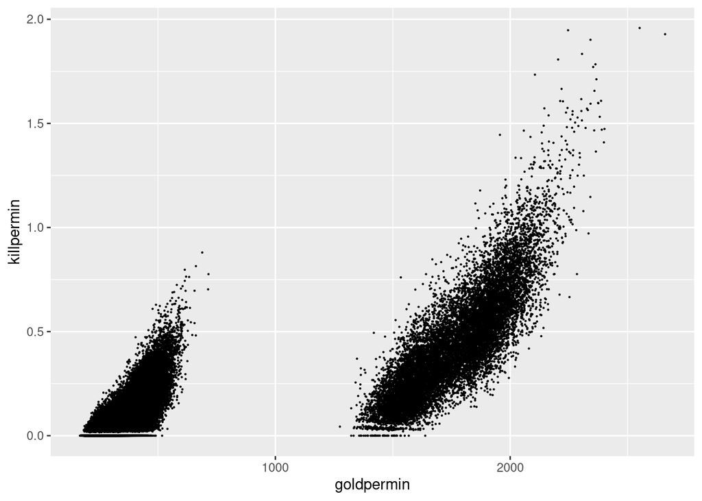

# 14 ‘Programation’ avec R

Nous savons déjà comment définir une fonction , il nous reste à voir comment écrire les traitements conditionnels, et les boucles.

## 14.1 Opérateurs logiques et de comparaisons

$$\begin{array}{|c|c|c|c|}
\hline
!x& NON\ logique &< &inférieur\ à\\
\hline
x \& y &ET\ logique &> &supérieur\ à\\
\hline
x \&\& y & idem* &<=& inférieur\ ou\ égal\ à\\
\hline
x | y &OU\ logique &>=& supérieur\ ou\ égal\ à\\
\hline
x || y &idem* &==& égal\\
\hline
xor(x, y)& OU\ exclusif &!=& différent\\
\hline
\end{array}$$

- Les opérateurs `&` et `&&` diffèrent en réalité , consulter la documentation pour saisir la nuance . Dans le doute, utilisez toujours la **version courte** .

## 14.2 Bloc `if`

Un bloc conditionnel s’écrit de la façon suivante :

```r
if (condition) {
  # code  éxécuté si condition vraie
}else{
  # code si condition fausse
}
```

La condition doit renvoyer une valeur **booléenne**, TRUE ou FALSE.

Comme en C, il y a une tolérance avec les valeurs qui reviennent au même : 1 et 0 , “TRUE” et “FALSE” , “T” et “F”.

### 14.2.1 Variante `ifelse`

Cette variante permet d’écrire une instruction conditionnelle sous une forme un peu plus compacte.

```r
ifelse(condition, valeur si vraie , valeur si fausse)
```

Voilà un exemple avec les penguins du package `palmerpenguins`, dont voici les variables :

```r
library(palmerpenguins)
names(penguins)
```

```
## [1] "species"           "island"            "bill_length_mm"
## [4] "bill_depth_mm"     "flipper_length_mm" "body_mass_g"
## [7] "sex"               "year"
```

Nous allons tester si la masse de chaque pingouin est inférieure ou supérieure à la moyenne de tous les pingouins du dataset :

```r
masse_moyenne <- mean(penguins$body_mass_g, na.rm = T)
ifelse(penguins$body_mass_g < masse_moyenne, "plus léger" , "plus lourd")
```

Voici les 6 premières valeurs que retourne ce traitement conditionnel :

```
## [1] "plus léger" "plus léger" "plus léger" NA           "plus léger"
## [6] "plus léger"
```

Notez l’effet de la valeur `NA`

## 14.3 Boucle `for`

La boucle for s’écrit de la façon suivante :

```r
for (variable in collection) {
  #code éxécuté pour chaque élément de la collection
}
```

```r
for (x in c(1,654,87,342,2,8,9)) {
  print(x)
}
```

```
## [1] 1
## [1] 654
## [1] 87
## [1] 342
## [1] 2
## [1] 8
## [1] 9
```

### 14.3.1 Sortie de boucle prématurée

pour interrompre une boucle for , on utilise le mot clé `break`

```r
for (x in c(1,2,3,4,5,6,7)) {
  print(x)
  if(x==4) {break}
}
```

```
## [1] 1
## [1] 2
## [1] 3
## [1] 4
```

### 14.3.2 Passer une itération

Pour passer une itération sans interrompre la boucle , on utilise le mot clé `next`

```r
for (x in c(1,2,3,4,5,6,7)) {
  if(x==3) {next}
  print(x)
}
```

```
## [1] 1
## [1] 2
## [1] 4
## [1] 5
## [1] 6
## [1] 7
```

## 14.4 Boucle `while`

La boucle `while` s’écrit de la façon suivante :

```r
while (condition) {
  #code
}
```

## 14.5 Applications vectorielles

les application vectorielles sont des variantes des traitements itératifs (boucle `for`),en R elles sont plus efficaces. Elles s’apparentent à de la programmation fonctionnelle. Les fonctions vectorielles de bases appliquent une fonction à tous les termes d’une collection ou d’une matrice. Les fonctions de base se nomment `sapply`, `lapply`, `vapply` pour traiter des vecteurs, et `apply`,`mapply` pour traiter des tableaux et des matrices. Consultez la documentation pour cerner les différences entre les fonctions de la famille.

Nous donnons ici un exemple simple :

```r
my_vec <-  seq(from=10, to=100, by=5)

my_func <- function(x){return(x+2)}
sapply(my_vec, my_func)
lapply(my_vec, my_func)
```

[output not shown]

Notez la différence du résultat de `sapply` et `lapply` en terme de type.

# 15 (Optionnel) Exercice #5

Implémentez en R le [crible d’ératosthène](https://fr.wikipedia.org/wiki/Crible_d%27%C3%89ratosth%C3%A8ne)

Vous pouvez vous inspirer du pseudo code suivant :

```
Fonction Eratosthène(Limite)
   L = tableau de booléen de taille Limite, initialisé à Vrai
   Mettre à Faux les cases d'indice pair > 2
   L[1] = Faux
   i=3
   Tant que i*i≤Limite
       Si L[i]
           Pour j de i*i à Limite par pas de 2*i
               L[j] = Faux
           Fin pour
       Fin si
       i=i+1
   Fin tant que
   Retourner L
Fin fonction
```